# Peer Assessment 1

Di Yang

April 17, 2015

### Loading and preprocessing the data

Load the data

```r
act <- read.csv("activity.csv")
```

Process/transform the data for analysis

```r
act$date <- as.Date(act$date, format="%Y-%m-%d")
```

### What is mean total number of steps taken per day?

Aggregate steps and date, then sum the rows

```r
spd <- aggregate(steps ~ date, data = act, FUN = sum)
```

Create histogram showing frequency of steps

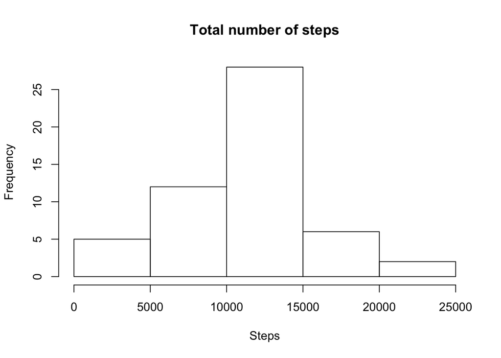

```r
hist(spd$steps,xlab="Steps",main="Total number of steps")
```

Calculate mean and median total number of steps taken per day

```r
summary(spd$steps)
```

```
##    Min. 1st Qu.  Median    Mean 3rd Qu.    Max.
##      41    8841   10760   10770   13290   21190
```

The median is 10760 and the mean is 10770.

### What is the average daily activity pattern?

Aggregate steps and intervals, sum the rows

```r
inte <- aggregate(steps ~ interval, data = act, FUN = sum)
```

Create histogram showing frequency of steps

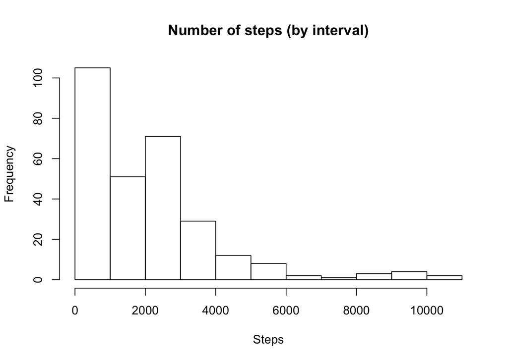

```r
hist(inte$steps,xlab="Steps",main="Number of steps (by interval)")
```

Aggregate steps and intervals, then find mean of rows

```r
avin <- aggregate(steps ~ interval, data = act, FUN = mean)
```

Create a time-series plot of intervals

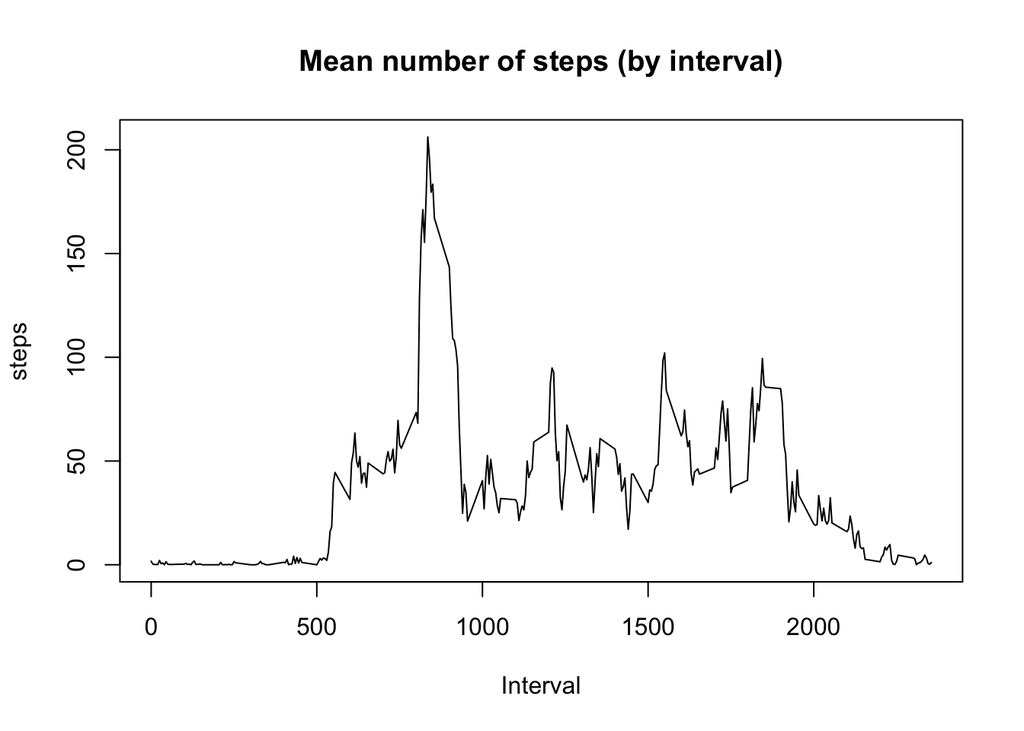

```r
plot(avin,xlab="Interval",main="Mean number of steps (by interval)",type="l")
```

Find interval with maximum step value (mean)

```r
avin[avin$steps==max(avin$steps),]
```

```
##     interval    steps
## 104      835 206.1698
```

### Imputing missing values

Calculate total number of missing values

```r
sum(!complete.cases(act))
```

```
## [1] 2304
```

There are 2,304 rows of missing values.

Replace NA values with mean value for that interval

```r
all <- transform(act, steps=ifelse(is.na(act$steps),
  avin$steps[match(act$interval, avin$interval)], act$steps))
```

Aggregate steps and date, then sum the rows

```r
aspd <- aggregate(steps ~ date, data = all, FUN = sum)
```

Create histogram of total steps per day with complete data

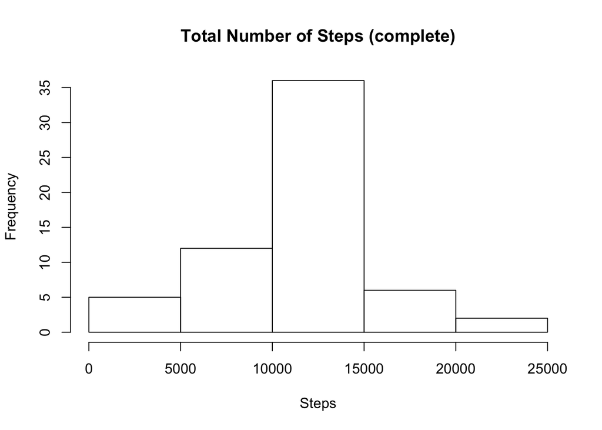

```r
hist(aspd$steps,xlab="Steps",main="Total Number of Steps (complete)")
```

Calculate the new mean and median total number of steps taken per day (for the complete data set)

```r
summary(aspd$steps)
```

```
##    Min. 1st Qu.  Median    Mean 3rd Qu.    Max.
##      41    9819   10770   10770   12810   21190
```

The median is 10770 and the mean is 10770.

For easy reference, here the old mean and median total number of steps taken per day (for the old data set)

```r
summary(spd$steps)
```

```
##    Min. 1st Qu.  Median    Mean 3rd Qu.    Max.
##      41    8841   10760   10770   13290   21190
```

### Are there differences in activity patterns between weekdays and weekends?

Create vector titled weekdays

```r
dayvalues <- c("Monday", "Tuesday", "Wednesday", "Thursday", "Friday")
```

Create a new column ‘daytype’ to specify if the day is a weekday or weekend. If the all$date value is a weekday, then the value for ‘daytype’ is ‘Weekday’. Else, the value for ‘daytype’ is ‘Weekend’.

```r
all$daytype = as.factor(ifelse(is.element(weekdays(all$date),dayvalues), "Weekday", "Weekend"))
```

Aggregate steps and interval by datetype, average the rows

```r
allw <- aggregate(steps ~ interval + daytype, all, mean)
```

Create a panel plot containing a time series plot (i.e. type = “l”) of the 5-minute interval (x-axis) and the average number of steps taken, averaged across all weekday days or weekend days (y-axis).

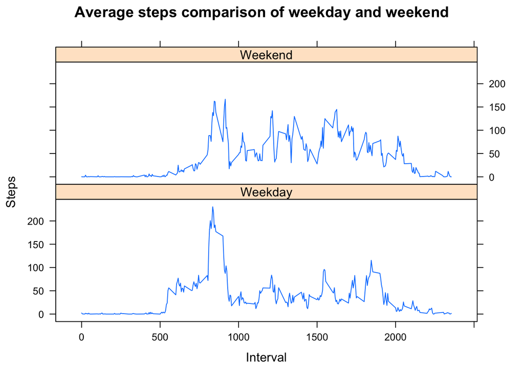

```r
library(lattice)
xyplot(allw$steps ~ allw$interval|allw$daytype, main="Average steps comparison of weekday and weekend",
  xlab="Interval", ylab="Steps",layout=c(1,2), type="l")
```